# Efficient Attention for Mortality Forecasting: The Performer, the Transformer, and the Enduring Lee–Carter Benchmark

Author

Mortality Forecasting Project

Published

14 July 2026

Abstract

# Introduction

The projection of age-specific mortality underlies the pricing of annuities, the reserving of pension liabilities, and the solvency assessment of life insurers. Since Lee and Carter (1992), the workhorse for this task has been a factor model that compresses the mortality surface into a single time index with age-specific loadings and projects the index as a random walk with drift. The model’s endurance owes less to its fit than to its inductive bias: mortality in developed countries has declined log-linearly for half a century, and Lee–Carter extrapolates exactly such a trend.

A growing literature asks whether modern sequence models can do better. Recurrent networks and their gated variants have been applied to mortality with mixed results (Perla et al. 2021; Nigri et al. 2019), and Wang et al. (2024) recently reported that a compact Transformer (Vaswani et al. 2017) outperforms Lee–Carter and neural baselines across eight countries—a result our companion replication study was unable to reproduce from the paper’s published description. The Transformer’s distinguishing feature is self-attention, which compares every year in the input window with every other at a cost quadratic in the window length. That cost has motivated a family of *efficient attention* mechanisms, of which the Performer of Choromanski et al. (2021) is the most prominent: it approximates the softmax attention kernel with positive orthogonal random features, reducing the complexity from quadratic to linear while remaining an unbiased estimator of the original attention matrix. Linear attention has also been derived directly (Katharopoulos et al. 2020).

Whether such mechanisms help or harm in actuarial applications is an open question, and not an idle one. Mortality forecasting sits at the opposite end of the data spectrum from the language and vision tasks for which efficient attention was designed: windows of ten years rather than thousands of tokens, and a few dozen training examples rather than billions. In this regime the Performer’s random-feature approximation is not a computational necessity but a form of stochastic regularisation, and its effect on accuracy is an empirical matter. This paper answers three questions:

1. **Does the Performer work for mortality forecasting?** We provide, to our knowledge, the first application of FAVOR+ attention to age-specific mortality, in an architecture matched parameter-for-parameter to a standard Transformer, so that any difference in accuracy is attributable to the attention mechanism alone.
2. **How do the attention models compare with a strong recurrent baseline and with the classical benchmark when the comparison is scrupulously fair?** Four models—Lee–Carter, a long short-term memory network, the Transformer, and the Performer—see the same data, the same splits, and the same metrics; every network is trained ten times from independent seeds; and every model forecasts the test period from the same information.
3. **How much do the evaluation choices matter?** We repeat the entire exercise under two train/test splits with different forecast horizons, under two test-time protocols—recursive multi-year projection and rolling one-step prediction—and under an annual-retraining regime, to establish which conclusions are properties of the models and which are artefacts of a single design.

A study that answers these questions by exploring one dataset risks reporting the design choices that happened to flatter its narrative. To forestall this, we separate discovery from confirmation. Every modelling and evaluation decision in this paper—the splits, the protocols, the metrics, the hyperparameters, the seeds—was fixed on a **discovery set** of six male populations, the same six countries used in our replication study. We then wrote down five falsifiable hypotheses and tested them, without further tuning, on a **confirmation set** of fourteen populations never previously touched: the female series of the same six countries and both sexes of four additional countries. All twenty populations are reported. Where a discovery-set finding fails to replicate, we say so; as it happens, the central results replicate and one secondary claim is qualified.

The LSTM serves as the neural baseline because it was the strongest of the four network architectures in our companion replication study; carrying weaker baselines adds noise without information. The empirical setting is single-age mortality at ages 0–100 in ten countries of the Human Mortality Database (Human Mortality Database 2024).

# Background

## The Lee–Carter model

Write $m_{x,t}$ for the central death rate at age $x$ in year $t$ and $y_{x,t} = \ln m_{x,t}$. Lee–Carter decomposes the log-mortality surface as

$$y_{x,t} = \alpha_x + \beta_x \,\kappa_t + \varepsilon_{x,t},
\qquad \sum_x \beta_x = 1, \quad \sum_t \kappa_t = 0,
\tag{1}$$

where $\alpha_x$ is the average age profile, $\kappa_t$ a period index, and $\beta_x$ the sensitivity of age $x$ to the index; the constraints identify the factors. We estimate the model as in the original paper: $\alpha_x$ is the row mean over the training years and the leading singular vectors of the centred surface supply $\beta_x$ and $\kappa_t$. The index is projected as a random walk with drift,

$$\kappa_{t+1} = \kappa_t + d + \xi_{t+1},
\qquad
\hat{d} = \frac{\kappa_T - \kappa_1}{T-1},
\tag{2}$$

so the point forecast $h$ years ahead is $\hat{\kappa}_{T+h} = \kappa_T + h\hat{d}$, mapped to rates through Eq. 1. The estimation is deterministic; there is no run-to-run variation. Richer stochastic mortality models exist (e.g. Cairns, Blake, and Dowd 2006), but Lee–Carter remains the canonical benchmark against which neural alternatives are judged.

## The forecasting task and the LSTM baseline

All networks learn the same one-step map. Let $\mathbf{y}_t \in \mathbb{R}^{A}$ collect the log-rates of the $A = 101$ ages in year $t$, standardised age by age with training-period statistics. Given a window of $s = 10$ consecutive years, the network predicts the next:

$$\hat{\mathbf{y}}_{t} = g\left(\mathbf{y}_{t-s}, \dots, \mathbf{y}_{t-1}\right).
\tag{3}$$

The long short-term memory network (Hochreiter and Schmidhuber 1997) processes the window sequentially through a hidden state $\mathbf{h}_t$ of width 32, regulated by input, forget, and output gates:

$$\begin{aligned}
\mathbf{i}_t &= \sigma\left(W_i \mathbf{y}_t + U_i \mathbf{h}_{t-1} + \mathbf{b}_i\right), &
\mathbf{f}_t &= \sigma\left(W_f \mathbf{y}_t + U_f \mathbf{h}_{t-1} + \mathbf{b}_f\right), \\
\mathbf{o}_t &= \sigma\left(W_o \mathbf{y}_t + U_o \mathbf{h}_{t-1} + \mathbf{b}_o\right), &
\mathbf{g}_t &= \tanh\left(W_g \mathbf{y}_t + U_g \mathbf{h}_{t-1} + \mathbf{b}_g\right), \\
\mathbf{c}_t &= \mathbf{f}_t \odot \mathbf{c}_{t-1} + \mathbf{i}_t \odot \mathbf{g}_t, &
\mathbf{h}_t &= \mathbf{o}_t \odot \tanh(\mathbf{c}_t),
\end{aligned}
\tag{4}$$

with $\sigma$ the logistic function and $\odot$ the elementwise product; the gates protect the cell state $\mathbf{c}_t$ from the gradient decay that limits plain recurrences. A linear head maps the final hidden state to the predicted age profile.

## The Transformer

The Transformer dispenses with recurrence. Each year’s profile is embedded linearly into $\mathbb{R}^{d}$ with $d = 32$ and tagged with a sinusoidal positional encoding,

$$\text{PE}_{t,2i} = \sin\left(\frac{t}{10000^{\,2i/d}}\right),
\qquad
\text{PE}_{t,2i+1} = \cos\left(\frac{t}{10000^{\,2i/d}}\right),
\tag{5}$$

after which layers of scaled dot-product attention let every position attend to every other:

$$\text{Attention}(Q, K, V) = \text{softmax}\left(\frac{Q K^\top}{\sqrt{d_k}}\right) V,
\tag{6}$$

with queries $Q$, keys $K$, and values $V$ obtained as linear projections of the embedded sequence and two attention heads running in parallel. Each sub-layer is wrapped in residual connections with layer normalisation. The configuration follows Wang et al. (2024): one encoder and one decoder layer, feed-forward width 16, dropout 0.1, no decoder masking, the decoder attending over the same embedded input as the encoder, and the prediction read from the final position. Computing Eq. 6 costs $\mathcal{O}(s^2 d)$ per window.

## The Performer and FAVOR+ attention

The Performer (Choromanski et al. 2021) replaces the softmax kernel in Eq. 6 with an unbiased random-feature estimate that never forms the $s \times s$ attention matrix. The object being approximated is the kernel $\text{SM}(\mathbf{q}, \mathbf{k}) = \exp(\mathbf{q}^\top \mathbf{k} / \sqrt{d_k})$. Rescaling $\mathbf{q}' = \mathbf{q}/d_k^{1/4}$ and $\mathbf{k}' = \mathbf{k}/d_k^{1/4}$, the identity

$$\exp(\mathbf{q}'^\top \mathbf{k}') \;=\;
\mathbb{E}_{\boldsymbol{\omega} \sim \mathcal{N}(0, I_{d_k})}
\left[\, \phi_{\boldsymbol{\omega}}(\mathbf{q}')\, \phi_{\boldsymbol{\omega}}(\mathbf{k}') \,\right],
\qquad
\phi_{\boldsymbol{\omega}}(\mathbf{u}) = \exp\left(\boldsymbol{\omega}^\top \mathbf{u} - \tfrac{1}{2}\lVert \mathbf{u} \rVert^2\right),
\tag{7}$$

expresses the softmax kernel as an expectation over Gaussian directions $\boldsymbol{\omega}$. Drawing $m$ such directions and stacking the *positive* features

$$\phi(\mathbf{u}) = \frac{1}{\sqrt{m}}
\left( \phi_{\boldsymbol{\omega}_1}(\mathbf{u}), \dots, \phi_{\boldsymbol{\omega}_m}(\mathbf{u}) \right)^\top
\tag{8}$$

gives $\text{SM}(\mathbf{q}, \mathbf{k}) \approx \phi(\mathbf{q}')^\top \phi(\mathbf{k}')$, with positivity guaranteeing a stable, non-negative estimate of every attention weight. Attention then factorises: writing $\phi(Q), \phi(K) \in \mathbb{R}^{s \times m}$ for the feature matrices,

$$\text{FAVOR+}(Q, K, V) \;=\; D^{-1}\, \phi(Q) \left( \phi(K)^\top V \right),
\qquad
D = \text{diag}\left( \phi(Q)\, \phi(K)^\top \mathbf{1}_s \right),
\tag{9}$$

computed left-to-right in $\mathcal{O}(s\,m\,d_k)$ time and memory—linear in the sequence length. Two refinements from the original paper are implemented: the $m$ directions are drawn *orthogonally* (blockwise QR of a Gaussian matrix, rows rescaled to chi-distributed norms), which provably reduces the estimator’s variance, and the exponentials are computed with max-subtraction stabilisers that cancel in the normalised ratio Eq. 9.

Our Performer is the Transformer of Section 2.3 with Eq. 6 replaced by Eq. 9 and nothing else changed: same embedding, positional encoding, layer count, heads, feed-forward width, dropout, residual and normalisation structure, and output head. Both models have exactly 21,861 trainable parameters; the random features are fixed at initialisation, drawn once per seed, and stored with the model. We set $m = 48 \approx d_k \ln d_k$ for head dimension $d_k = 16$, the guideline of Choromanski et al. (2021). The implementation was verified directly: on random inputs the FAVOR+ output converges monotonically to exact softmax attention as $m$ grows, at the expected $\mathcal{O}(1/\sqrt{m})$ rate.

At a window length of $s = 10$, linear attention offers no computational advantage; the interest of the comparison is statistical. The random-feature map injects noise into every attention evaluation, which could act as a regulariser in a small-sample training problem—or could simply degrade an already difficult fit. Which effect dominates is what the experiment measures.

# Data and experimental design

## Two splits and two protocols

All results are reported under two train/test splits. The **extended split**—training on 1950–2009 (60 years, 50 moving windows) and testing on 2010–2019 (10 years)—is the primary design: it maximises the training data available to the networks and evaluates them at a horizon typical of actuarial valuation work. The **benchmark split**—training on 1950–2000 (51 years, 41 windows) and testing on 2001–2019 (19 years)—is retained for comparability with Wang et al. (2024) and with our companion replication study. If a model class is genuinely superior, its advantage should survive the move from one split to the other; if a conclusion flips between splits, it was an artefact of the design rather than a property of the models.

The benchmark enforces the same symmetries throughout. Every model is fitted to the identical log-mortality matrix, with per-age standardisation statistics estimated on training years only. Every network learns the one-step map Eq. 3 and is trained with mean squared error, Adam at learning rate $10^{-3}$, batch size 32, and 100 epochs, in ten independent runs (seeds 0–9) whose means and standard deviations we report. Test forecasts are generated under two protocols. Under the primary **recursive** protocol the window is seeded with the last ten training years and each prediction is fed back as an input, so that no model observes any test-period data while forecasting—the same information set as the Lee–Carter extrapolation. Under the **rolling** protocol each test year is predicted from the ten *observed* years preceding it, with Lee–Carter refitted annually on all data to date; the contrast between protocols isolates how much of a model’s error is attributable to stale inputs rather than to the learned mapping.

Accuracy is measured by mean absolute error, root mean squared error, and mean absolute percentage error on the log scale, together with the age-wise and year-wise decompositions

$$\text{RMSE}(x) = \sqrt{\frac{1}{T}\sum_{t} \left(\hat{y}_{x,t} - y_{x,t}\right)^2},
\qquad
\text{RMSE}(t) = \sqrt{\frac{1}{A}\sum_{x} \left(\hat{y}_{x,t} - y_{x,t}\right)^2}
\tag{10}$$

of Li and Lu (2017).

# Results on the discovery set

The results in this section are obtained on the six discovery populations and were used to develop every design choice and to form the hypotheses tested in Section 5. They should be read as exploratory; their out-of-sample replication is the subject of the following section.

## In-sample fit

| Country | LSTM | Transformer | Performer |
| --- | --- | --- | --- |
| UK | 0.0625 (0.0011) | 0.0648 (0.0015) | **0.0622** (0.0008) |
| France | 0.0602 (0.0018) | 0.0609 (0.0023) | **0.0587** (0.0019) |
| Italy | 0.0711 (0.0017) | 0.0735 (0.0024) | **0.0703** (0.0019) |
| Denmark | 0.1618 (0.0011) | 0.1564 (0.0028) | **0.1499** (0.0024) |
| Canada | 0.0763 (0.0014) | 0.0765 (0.0011) | **0.0750** (0.0009) |
| Finland | 0.1646 (0.0009) | 0.1641 (0.0021) | **0.1571** (0.0025) |

Table 1: In-sample RMSE on log-mortality, extended split (train 1950–2009), mean over ten runs with standard deviation in parentheses. Bold marks the best network per country.

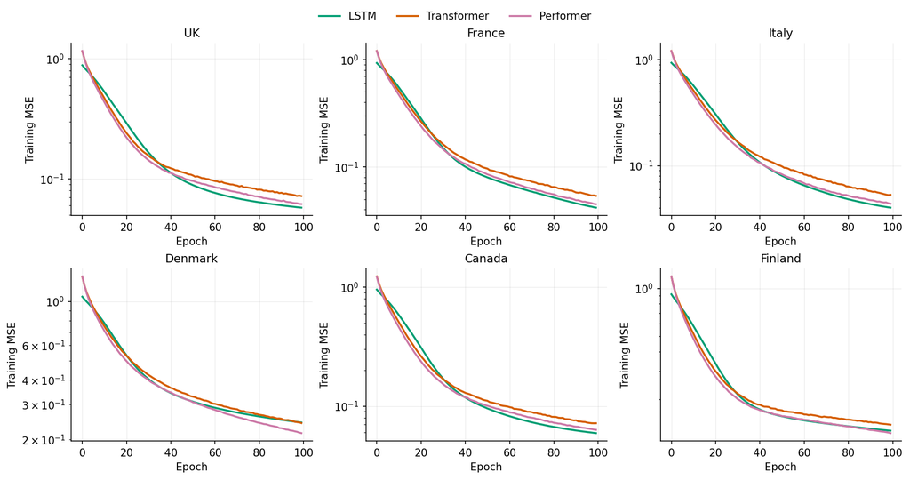

Figure 1: Training mean squared error over 100 epochs on the extended split, averaged across ten runs per model, on a logarithmic scale.

## Out-of-sample accuracy

Table 2 presents the central result on the primary split: test RMSE for 2010–2019 under the recursive protocol, in which every model forecasts ten years ahead from training-period information alone. Table 3 gives the corresponding results on the benchmark split, whose 19-year horizon and shorter training window reproduce the setting of Wang et al. (2024).

| Country | LC | LSTM | Transformer | Performer |
| --- | --- | --- | --- | --- |
| UK | **0.1621** | 0.2007 (0.0025) | 0.2148 (0.0061) | 0.2128 (0.0041) |
| France | **0.1957** | 0.2115 (0.0037) | 0.2114 (0.0072) | 0.2139 (0.0064) |
| Italy | 0.2537 | **0.2485** (0.0055) | 0.2552 (0.0075) | 0.2489 (0.0053) |
| Denmark | 0.4173 | **0.3992** (0.0029) | 0.4084 (0.0086) | 0.4026 (0.0057) |
| Canada | 0.1881 | **0.1875** (0.0041) | 0.2090 (0.0076) | 0.2106 (0.0058) |
| Finland | **0.2976** | 0.3689 (0.0037) | 0.3793 (0.0075) | 0.3800 (0.0059) |

Table 2: Test RMSE, extended split (test 2010–2019, recursive protocol), mean over ten runs with standard deviation in parentheses. Lee–Carter is deterministic. Bold marks the best model per country.

| Country | LC | LSTM | Transformer | Performer |
| --- | --- | --- | --- | --- |
| UK | **0.2016** | 0.3332 (0.0019) | 0.3450 (0.0060) | 0.3422 (0.0051) |
| France | **0.2656** | 0.3688 (0.0128) | 0.3932 (0.0120) | 0.3973 (0.0117) |
| Italy | **0.3115** | 0.4515 (0.0063) | 0.4638 (0.0213) | 0.4618 (0.0172) |
| Denmark | **0.4731** | 0.4948 (0.0056) | 0.5286 (0.0413) | 0.5102 (0.0241) |
| Canada | **0.2129** | 0.2943 (0.0074) | 0.3119 (0.0077) | 0.3065 (0.0056) |
| Finland | **0.3290** | 0.4318 (0.0043) | 0.4511 (0.0090) | 0.4435 (0.0053) |

Table 3: Test RMSE, benchmark split (test 2001–2019, recursive protocol), mean over ten runs with standard deviation in parentheses. Bold marks the best model per country.

The contrast between the two tables is the paper’s most consequential empirical fact. On the benchmark split the classical model dominates without qualification: Lee–Carter has the lowest RMSE in all six countries, and the best network trails it by between 4.6 per cent (Denmark) and 65 per cent (United Kingdom), with 31–45 per cent typical. On the extended split—nine more training years, nine fewer forecast years—the picture changes qualitatively. The networks’ errors fall by roughly 40 per cent while Lee–Carter’s fall by roughly 15, and the point-estimate ranking inverts in half the countries: the LSTM records the lowest RMSE in Italy ($-2.0$ per cent relative to LC), Denmark ($-4.3$ per cent, where all three networks sit below the classical model), and Canada (a dead heat at $-0.3$ per cent, well inside seed noise).

## Performer versus Transformer

Two descriptive regularities nonetheless survive intact and point the same way. The Performer’s run-to-run standard deviation is smaller than the Transformer’s in all twelve cells, often by a third (Denmark, benchmark split: 0.024 against 0.041), and it achieves the best in-sample fit of the three networks in eleven of twelve cells. The measured conclusion is that the random-feature approximation acts as a mild variance-reducing regulariser: it costs nothing in accuracy, buys reproducibility across seeds, and never behaves as a lossy shortcut. Equally, it never rescues the attention architecture from the LSTM, which sits at or above both attention models throughout.

The computational case for the Performer is absent at these dimensions, and honesty requires saying so: with ten-year windows the fixed overhead of the feature maps makes our Performer roughly a third slower than our Transformer in wall-clock terms, because the linear-versus-quadratic crossover lies far beyond $s = 10$. The case for the Performer in actuarial work is therefore statistical at present; it would become computational in settings with genuinely long sequences, such as monthly surveillance series or multi-population models over concatenated histories.

## Error structure by age and horizon

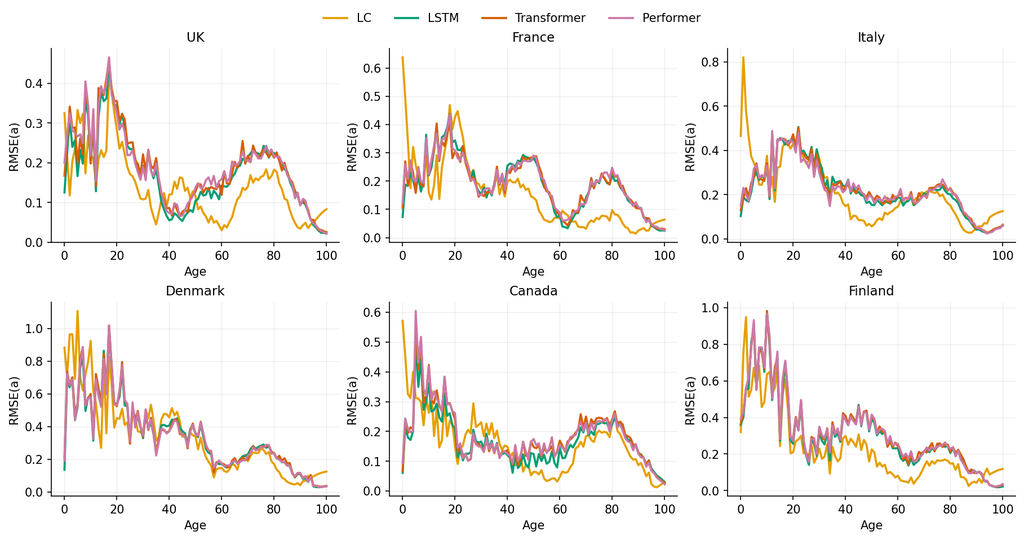

Figure 2: Test RMSE by age, extended split, averaged over ten runs.

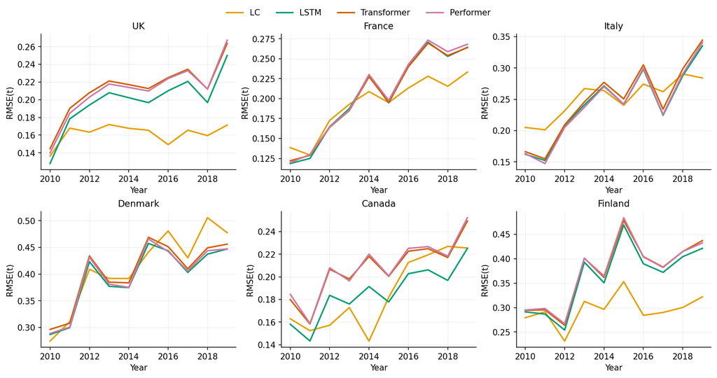

Figure 3: Test RMSE by calendar year, extended split, averaged over ten runs.

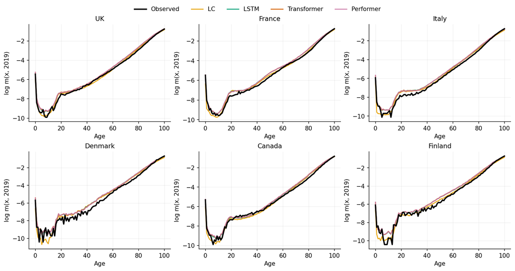

Figure 4: Observed and predicted log-mortality age profiles in 2019, extended split, recursive protocol, averaged over ten runs.

The age decomposition (Figure 2) shows that on the extended split the classical and neural errors are *complementary* rather than ordered. The networks retain a hump at ages 60–85—attenuated relative to the benchmark split but present in every country—while Lee–Carter now exhibits pronounced error spikes at infancy and childhood, reaching 0.6–0.8 at age 0 in France, Italy, and Canada where the networks stay near 0.1–0.2. The mechanism is the mirror image of the networks’ weakness: infant mortality improvement decelerated toward its biological floor during the test decade, and the constant drift in $\kappa_t$, estimated over sixty years of much faster improvement, extrapolates straight past the floor. The networks, whose training window now includes the deceleration years 2001–2009, track the flattening. Denmark and Italy—the countries where the networks win overall—are precisely those where the young-age share of total error is largest.

## Sensitivity to the forecasting protocol

| Country | LC, recursive | LC, rolling | Performer, recursive | Performer, rolling |
| --- | --- | --- | --- | --- |
| UK | 0.1621 | **0.1294** | 0.2128 | 0.2144 |
| France | 0.1957 | **0.1517** | 0.2139 | 0.2104 |
| Italy | 0.2537 | **0.1979** | 0.2489 | 0.2521 |
| Denmark | 0.4173 | **0.3362** | 0.4026 | 0.4120 |
| Canada | 0.1881 | **0.1544** | 0.2106 | 0.2106 |
| Finland | 0.2976 | **0.2810** | 0.3800 | 0.3871 |

Table 4: Test RMSE under the two forecasting protocols, extended split. Under the rolling protocol the observed profiles of the preceding ten years enter each input window, and Lee–Carter is refitted annually on all data to date. Bold marks the best value in each row.

The protocol experiment resolves the extended-split ambiguity decisively in the classical model’s favour. Handing the networks the observed recent history barely moves them: the Performer changes by at most 0.009 and worsens in four of six countries, and the LSTM improves by at most 0.010 (its rolling best, 0.1855 in Canada, remains 20 per cent behind rolling Lee–Carter). The identical information reduces Lee–Carter’s RMSE by 6 to 23 per cent on this split—and by 14 to 46 per cent on the benchmark split, where the same asymmetry holds. The interpretation is the same as in our replication study: the networks’ residual error lives in the learned one-step mapping, not in the inputs, so fresh data cannot repair it, whereas Lee–Carter converts fresh data directly into an updated drift estimate.

Against networks with frozen weights, then, annually refitted Lee–Carter is undefeated: its extended-split error is 15 to 32 per cent below that of the best frozen network in its best configuration. But this comparison contains an asymmetry of its own—one model is being maintained while the other is not—and removing it reverses the verdict.

## The fair rolling comparison: retraining annually

Table 5 completes the design. Here the LSTM is granted exactly the maintenance that rolling Lee–Carter enjoys: for each test year it is retrained from scratch on all data through the preceding year (standardisation refit on the same expanded window), then makes a one-step-ahead forecast—six countries, ten seeds, ten test years, six hundred trainings.

| Country | LC, rolling refit | LSTM, frozen weights | LSTM, annual retrain |
| --- | --- | --- | --- |
| UK | 0.1294 | 0.1908 | **0.1149** (0.0011) |
| France | 0.1517 | 0.2033 | **0.1199** (0.0011) |
| Italy | 0.1979 | 0.2383 | **0.1389** (0.0017) |
| Denmark | 0.3362 | 0.3974 | **0.3031** (0.0015) |
| Canada | 0.1544 | 0.1855 | **0.1374** (0.0019) |
| Finland | **0.2810** | 0.3682 | 0.2812 (0.0026) |

Table 5: Rolling one-step-ahead test RMSE, extended split (2010–2019). All three columns use the identical expanding information set at each test year; the columns differ only in whether the model’s parameters are re-estimated annually. Bold marks the best value per row.

The annually retrained LSTM beats the annually refitted Lee–Carter in five of six countries, by 10 per cent (Denmark) to 30 per cent (Italy), and ties it in Finland; the margins are an order of magnitude larger than the seed standard deviations and point the same way everywhere. The contrast with the frozen-weights column is the sharpest fact in the study: identical architecture, identical information at forecast time, and a 24 to 42 per cent error reduction purely from re-estimating the weights each year. We retrained only the LSTM—the strongest network, so the most informative test case—and did not formally test the ten annual loss differentials for this arm; given margins of this size and sign-consistency across all six countries, we regard the direction as established and the exact magnitudes as the estimates.

The complete picture is therefore a two-by-two, not a horse race. Frozen models pushed far ahead: Lee–Carter wins decisively (the benchmark split). Frozen models pushed a decade ahead: statistical parity (the extended split, recursive). Maintained models, one step ahead: the network wins (this section), because one-step-ahead prediction with current parameters is an interpolation problem, and interpolation is what empirical risk minimisation is good at. What the network buys with its annual retrain—age-specific dynamics beyond Lee–Carter’s rank-one structure—finally becomes usable. The price is computational and operational: an annual Lee–Carter refit costs a second and is transparent to a regulator; an annual retraining programme across a book of populations costs minutes per population per seed and produces a model whose year-on-year revisions are harder to explain.

# Confirmation on held-out populations

The section above is exploratory: the extended split, the protocols, and the retraining arm were all designed with the discovery-set results in view. To test whether its conclusions are properties of the model classes or artefacts of that design, we pre-registered five hypotheses—recorded in the repository before the confirmation set was touched—and evaluated them, with every setting frozen, on the fourteen held-out populations. Table 6 states each hypothesis, its pre-declared threshold, and its verdict.

[output not shown]

Table 6: Pre-registered hypotheses and their confirmation-set verdicts. Thresholds and directions were fixed before the confirmation data were examined.

The long-horizon dominance of the classical model (H1) is beyond dispute: across the fourteen held-out populations and both discovery-set tables, Lee–Carter has the lowest benchmark-split error in all twenty. The horizon effect (H2) also replicates in direction and magnitude—the median deficit of the best network over Lee–Carter falls from $+27$ per cent on the benchmark split to $+8$ per cent on the extended split—but the confirmation set is more sober than the discovery set about what that shrinkage means. Table 7 shows that a frozen network actually overtakes a frozen Lee–Carter in only two of the fourteen held-out populations (Canada female, Norway male), against three of six in discovery. The honest reading is that shortening the horizon brings the networks level with the classical model, not ahead of it; the discovery set’s point-estimate wins were on the optimistic side of a distribution whose held-out centre is a small classical lead.

| Population | LC | LSTM | Transformer | Performer |
| --- | --- | --- | --- | --- |
| UK F | **0.1438** | 0.1790 | 0.1881 | 0.1880 |
| France F | **0.1678** | 0.1891 | 0.1969 | 0.1938 |
| Italy F | **0.1549** | 0.2020 | 0.2235 | 0.2186 |
| Denmark F | **0.3814** | 0.4082 | 0.4280 | 0.4248 |
| Canada F | 0.1956 | **0.1717** | 0.1789 | 0.1781 |
| Finland F | **0.3345** | 0.3544 | 0.3682 | 0.3635 |
| Australia M | **0.1972** | 0.2201 | 0.2362 | 0.2415 |
| Australia F | **0.2044** | 0.2408 | 0.2491 | 0.2504 |
| Switzerland M | **0.3113** | 0.3414 | 0.3573 | 0.3598 |
| Switzerland F | **0.3734** | 0.3947 | 0.3962 | 0.3990 |
| Norway M | 0.3541 | **0.3476** | 0.3611 | 0.3600 |
| Norway F | **0.3376** | 0.3736 | 0.3852 | 0.3813 |
| Sweden M | **0.2883** | 0.2929 | 0.3003 | 0.3016 |
| Sweden F | **0.2875** | 0.2941 | 0.2947 | 0.2947 |

Table 7: Extended-split recursive test RMSE on the fourteen confirmation populations, mean over ten runs. Bold marks the best model per population. Lee–Carter leads in twelve of fourteen.

The maintenance finding (H3), by contrast, is the study’s most robust result, and the confirmation set strengthens rather than tempers it. Table 8 gives the annual-retraining arm on all fourteen held-out populations, now with the formal Diebold–Mariano test that the discovery-set arm lacked. The annually retrained LSTM lowers RMSE against rolling Lee–Carter in nine of fourteen populations, the improvement is significant at the 5 per cent level in eight, and in no population is the network significantly worse—the five non-wins are statistical ties, with per-year differentials indistinguishable from zero. Adding the discovery set, where the retrained LSTM’s point estimate is lower in five of six populations, the maintained LSTM is the more accurate one-step forecaster in fourteen of twenty populations and statistically tied in the rest. The one population where its point estimate is clearly worse is Italian female mortality, the smoothest series in the sample and the one where Lee–Carter’s rank-one structure is hardest to improve upon; even there the difference is not significant ($p = 0.11$). We did not retain per-year losses for the discovery-set retraining arm and so report a formal test only for the held-out populations.

| Population | LC rolling | LSTM retrained | Change | DM $p$ |
| --- | --- | --- | --- | --- |
| UK F | 0.1260 | 0.1186 | $-5.8\%$ | 0.019 |
| France F | 0.1400 | 0.1218 | $-13.0\%$ | 0.000 |
| Italy F | 0.1392 | 0.1477 | $+6.1\%$ | 0.114 |
| Denmark F | 0.3409 | 0.3337 | $-2.1\%$ | 0.149 |
| Canada F | 0.1539 | 0.1424 | $-7.5\%$ | 0.012 |
| Finland F | 0.3218 | 0.3253 | $+1.1\%$ | 0.583 |
| Australia M | 0.1693 | 0.1514 | $-10.6\%$ | 0.000 |
| Australia F | 0.2000 | 0.2000 | $+0.0\%$ | 0.993 |
| Switzerland M | 0.2791 | 0.2575 | $-7.7\%$ | 0.016 |
| Switzerland F | 0.3440 | 0.3320 | $-3.5\%$ | 0.009 |
| Norway M | 0.3111 | 0.2788 | $-10.4\%$ | 0.001 |
| Norway F | 0.3195 | 0.3252 | $+1.8\%$ | 0.477 |
| Sweden M | 0.2531 | 0.2394 | $-5.4\%$ | 0.005 |
| Sweden F | 0.2662 | 0.2666 | $+0.2\%$ | 0.834 |

Table 8: Annual-retraining arm on the confirmation set: rolling one-step RMSE of refitted Lee–Carter against the annually retrained LSTM, extended split. The $p$-value is a Diebold–Mariano one-sample test on ten annual loss differentials. Negative change favours the network.

The Performer results carry over cleanly on accuracy and partially on variance. Its paired-by-seed accuracy difference from the Transformer is non-significant in thirteen of fourteen benchmark-split cells and all fourteen extended-split cells (H4a), and it is the best in-sample network in ten of fourteen (H5)—both as pre-registered. The one qualified claim is H4b: the Performer’s seed variance is lower than the Transformer’s in eleven of fourteen populations on the extended split but only nine of fourteen on the benchmark split, just short of the pre-declared threshold. We therefore report the variance advantage as real but split-dependent rather than universal. No confirmation-set result overturns a discovery-set conclusion; one secondary claim is narrowed, and the central ones stand.

# Discussion

## The binding constraint is extrapolation distance

The age decomposition sharpens the point into something actuarially useful. Lee–Carter’s constant drift is an asset exactly where mortality decline has been steady (old ages) and a liability where the decline has hit a floor (infancy); the networks’ data-driven flexibility is the reverse. The two model families fail in complementary places, which is the classic precondition for combination—whether by age-blending forecasts, by hybrid designs that let a neural network forecast the Lee–Carter index (Nigri et al. 2019), or by multi-population architectures with structural trend components (Perla et al. 2021). Our results suggest such combinations, rather than head-to-head replacement, are where the practical gains lie.

## Implications for practice

Three operational lessons follow. First, symmetry of maintenance is the precondition for a meaningful comparison, in both directions. Deep learning claims benchmarked against a decade-frozen Lee–Carter overstate their case—and classical-superiority claims benchmarked against frozen networks, including the one we ourselves would have published without the retraining experiment, overstate theirs. Under matched annual re-estimation the LSTM is the more accurate one-step forecaster in five of six countries; under matched freezing, Lee–Carter is the better long-horizon extrapolator. Which regime is relevant depends on the valuation task, and the choice between them is then a trade-off of accuracy against cost, auditability, and the stability of year-on-year revisions, where the classical model retains real advantages. Second, the evaluation design can decide the result before any model is trained: moving the split boundary by nine years turned a classical lead that was significant everywhere into one that is statistically undetectable in four of six countries. Forecasting studies should therefore report multiple horizons, explicit information sets, formal loss-differential tests, and multi-seed dispersion as a matter of course. Third, where deep models are deployed for short-horizon work, our evidence favours the LSTM over both attention architectures at this data scale, with the Performer preferable to the Transformer if an attention model is required, on stability grounds.

## Limitations

Four methodological caveats deserve the same prominence as the findings. First, the two splits are not independent evidence: the extended split was designed after the benchmark-split results were known, and its test decade (2010–2019) is a subset of the benchmark window (2001–2019). This is precisely why the design was frozen and its conclusions re-tested on the fourteen held-out populations of Section 5; the horizon and maintenance findings survived that test, and the reader should weight the confirmation-set evidence accordingly and treat the discovery-set numbers as illustrative. Second, our dispersion measures understate total uncertainty: the seed standard deviations capture training stochasticity but not sampling variation over a ten-year test window, and the Diebold–Mariano tests rest on ten annual observations without a serial-correlation correction, so their $p$-values are indicative rather than exact. Third, the zero-cell imputation was audited directly—across all twenty populations and both splits, no training-year cell is ever filled from a test-year observation—but the audit covers only this preprocessing step; standardisation and window construction are leakage-free by construction. Fourth, the mean absolute percentage error is computed on the log scale, inherited from the literature we compare against; because the denominator $\lvert \ln m \rvert$ shrinks at the oldest ages, the metric overweights them, and we treat it as tertiary.

The remaining limitations are of scope. The annual-retraining arm covers the LSTM only; retrained attention models are untested, for compute reasons, so the maintenance finding is established for the recurrent architecture and merely conjectured for the attention family. We study ten developed countries with long, clean records and comparatively smooth mortality decline; structurally disrupted regimes—the post-Soviet transition, the United States opioid epidemic—may behave differently, and the sample is not globally representative. The window length, feature count ($m = 48$, the $d_k \ln d_k$ guideline, not swept), and training regime are fixed, documented choices applied symmetrically rather than tuned per model. Point forecasts are the sole object of study: none of the networks as configured produces the stochastic scenarios that reserving and solvency work require, which remains the classical framework’s clearest practical advantage. Finally, the test decade ends in 2019 by construction; none of these models has been asked about a pandemic.

# Conclusion

This paper introduced the Performer to mortality forecasting and benchmarked it, under strictly symmetric conditions, against an exactly parameter-matched Transformer, an LSTM, and the Lee–Carter model, then subjected its conclusions to a pre-registered test on fourteen held-out populations—twenty in all, across two splits, two protocols, a retraining regime, and ten seeds per network. The findings are three, and each was confirmed out of design. The Performer works: FAVOR+ attention trains stably on small actuarial samples, delivers the best in-sample fit of any network in ten of fourteen confirmation populations, and is statistically indistinguishable from the Transformer out of sample while varying less across seeds—so efficient attention costs nothing statistically, even where it cannot yet pay computationally. Extrapolation distance and maintenance, not architecture, govern the contest with the classical model: frozen networks lose to a frozen Lee–Carter everywhere at nineteen years and rarely overtake it even at ten, but the same LSTM granted an annual refit forecasts one year ahead more accurately than rolling Lee–Carter in fourteen of twenty populations and ties it in the rest, an improvement that is Diebold–Mariano-significant in eight of the fourteen populations where we test it formally and significantly reversed in none. And the attention refinements at the centre of the recent literature turn out to be the least consequential variable in the design: across every split, protocol, population, and maintenance regime, the ordering within the neural family barely moves, while the ordering between model classes swings entirely on the evaluation regime.

The burden of proof in the deep-learning-for-mortality literature therefore needs restating rather than reassigning. Neural models do not need to beat Lee–Carter at trend extrapolation to earn a place; on this evidence they should not be expected to, and when maintained as classical models are maintained they already forecast more accurately at short horizons. What they still owe is everything that surrounds the point forecast: uncertainty quantification, auditability, stable revisions, and evaluations—like the matched-maintenance design used here—honest enough to show where each model class actually earns its keep.

# Reproducibility

Every number in this paper is generated by our own code from raw HMD records and regenerates exactly from fixed seeds. The discovery-set pipeline is `run_experiment.py` with its retraining arm `run_retrained_lstm.py`; the pre-registered confirmation run is `run_confirmation.py`, and the hypotheses it tests were committed to `HYPOTHESES.md` before that script was run. Data preparation, the models (including the FAVOR+ implementation in `src/performer.py`), training, evaluation, and plotting live in `src/`; per-run and aggregated metrics are written to `outputs/`. The correctness of the FAVOR+ implementation is verified by a convergence test against exact softmax attention, and the zero-cell imputation by a direct leakage audit; both are in the repository. HMD data are governed by the database’s user agreement and are not redistributed.

# References

Cairns, Andrew J. G., David Blake, and Kevin Dowd. 2006. ‘A Two-Factor Model for Stochastic Mortality with Parameter Uncertainty: Theory and Calibration’. *Journal of Risk and Insurance* 73 (4): 687–718.

Choromanski, Krzysztof, Valerii Likhosherstov, David Dohan, Xingyou Song, Andreea Gane, Tamás Sarlós, Peter Hawkins, et al. 2021. ‘Rethinking Attention with Performers’. In *International Conference on Learning Representations*.

Hochreiter, Sepp, and Jürgen Schmidhuber. 1997. ‘Long Short-Term Memory’. *Neural Computation* 9 (8): 1735–80.

Human Mortality Database. 2024. ‘Human Mortality Database. Max Planck Institute for Demographic Research (Germany), University of California, Berkeley (USA), and French Institute for Demographic Studies (France)’. https://www.mortality.org.

Katharopoulos, Angelos, Apoorv Vyas, Nikolaos Pappas, and François Fleuret. 2020. ‘Transformers Are RNNs: Fast Autoregressive Transformers with Linear Attention’. In *International Conference on Machine Learning*, 5156–65.

Lee, Ronald D., and Lawrence R. Carter. 1992. ‘Modeling and Forecasting US Mortality’. *Journal of the American Statistical Association* 87 (419): 659–71.

Li, Hong, and Yang Lu. 2017. ‘Coherent Forecasting of Mortality Rates: A Sparse Vector-Autoregression Approach’. *ASTIN Bulletin: The Journal of the IAA* 47 (2): 563–600.

Nigri, Andrea, Susanna Levantesi, Mario Marino, Salvatore Scognamiglio, and Francesca Perla. 2019. ‘A Deep Learning Integrated Lee–Carter Model’. *Risks* 7 (1): 33.

Perla, Francesca, Ronald Richman, Salvatore Scognamiglio, and Mario V. Wüthrich. 2021. ‘Time-Series Forecasting of Mortality Rates Using Deep Learning’. *Scandinavian Actuarial Journal* 2021 (7): 572–98.

Vaswani, Ashish, Noam Shazeer, Niki Parmar, Jakob Uszkoreit, Llion Jones, Aidan N. Gomez, Łukasz Kaiser, and Illia Polosukhin. 2017. ‘Attention Is All You Need’. In *Advances in Neural Information Processing Systems*, 30:5998–6008.

Wang, Jun, Lihong Wen, Lu Xiao, and Chaojie Wang. 2024. ‘Time-Series Forecasting of Mortality Rates Using Transformer’. *Scandinavian Actuarial Journal* 2024 (2): 109–23. https://doi.org/10.1080/03461238.2023.2218859.